## Homework Assignment 12

### Preliminaries

- Directories
  - COURSE/homework/
  - COURSE/homework/hw12/
  - COURSE/data/
  - COURSE/scripts/
- Files
  - COURSE/homework/hw12/hw12.Rmd
  - COURSE/data/lake-monona-winters-2022.csv
  - COURSE/scripts/viridis.R
  - COURSE/scripts/ggprob.R

### Aims

- Practice regression inference

## Problems

### 1

Fit a linear model to predict the value of $y$ (the date where Lake Monona first freezes measured in days after June 30) as a function of the first year of the winter, `year1`.

- Report the coefficients of this linear model.

### 2

- Use the **modelr** functions `add_residuals()` and `add_predictions()` to add columns for the residuals and predictions to the fitted model.
- Make a plot of the residuals versus the first year of winter.
  - Add a horizontal line with y-intercept zero.
- Comment on patterns in the residual plot which may or may not suggest either non-linearity or non-constant variance

### 3

- Create a 95% confidence interval for the slope parameter. (The interval is calculated as $\text{(Estimate)} \pm t^*\text{(SE)}$ where $t^*$ is an appropriate critical quantile from a t distribution with $n-2$ degrees of freedom in the case of simple linear regression.)
- Interpret the confidence interval in context.

You may use `summary()` to print the linear model summary. Alternatively, the following function returns the standard errors from the fitted linear model object as a base R vector.

```r
## example usage
## model = lm(y ~ x)
## se = lm_se(model)
##
lm_se = function(model)
{
  return ( sqrt(diag(vcov(model))) )
}
```

### 4

- Assume that a linear model between the first freeze date (coded as #days after June 30) and first year of winter is appropriate for the Lake Monona data and that you can interpret this model as a feature of the climate in Madison over time for the past 160+ years.
- Examine code below which creates a 95% confidence interval for the expected date for Lake Monona to first freeze in the winter of 2022-2023. *(Note: the fitted regression line is an estimate of the location of this hypothetical feature of climate change over time.)*
- Interpret the confidence interval in context (use actual dates rather than coded days after June 30).
- Make a scatter plot of the coded first freeze date versus year and add the plot of a regression line with a ribbon using `geom_smooth()`.
- Explain what feature of the ribbon corresponds to the confidence interval you calculated.

```r
## confidence interval using predict()
new_data = tibble(
  year1 = 2022
)

predict(monona_lm, new_data, interval = "confidence") %>%
  round(digits = 1)
```

```
##     fit   lwr   upr
## 1 175.9 172.4 179.3
```

### 5

- The following block of code uses a fitted linear model to create a 95% prediction interval for the individual date in the 2022-2023 winter when Lake Monona will first freeze.
- Interpret the interval in context (use dates and not numerical values).
- Explain what feature of the provided plot corresponds to this prediction interval.

```r
predict(monona_lm, new_data, interval = "prediction") %>%
  round(digits = 1)
```

```
##     fit   lwr upr
## 1 175.9 153.7 198
```

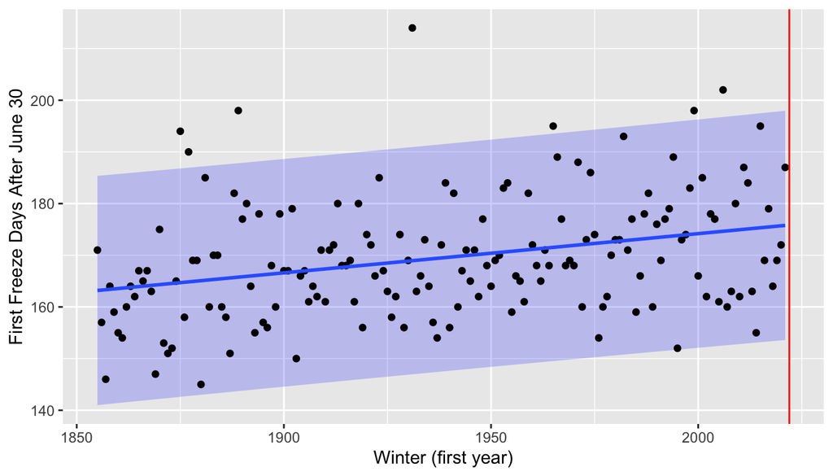

```r
full_prediction = predict(monona_lm, monona,
                          interval = "prediction") %>%
  as_tibble()

monona = monona %>%
  mutate(pred_lwr = full_prediction$lwr,
         pred_upr = full_prediction$upr)

ggplot(monona, aes(x = year1, y = y)) +
  geom_ribbon(aes(ymin = pred_lwr, ymax = pred_upr),
              alpha = 0.2, fill = "blue") +
  geom_point() +
  geom_smooth(method = "lm", se = FALSE) +
  geom_vline(xintercept = 2022, color = "red") +
  xlab("Winter (first year)") +
  ylab("First Freeze Days After June 30")
```

### 6

- What is the unit of measurement for $\hat{\sigma}$?

Assume that a linear model between `y` (date of the first freeze after June 30) and `year1` (first year of the winter) is appropriate for another 100 years.

- Without making a calculation, using the 167 years of data from the winter of 1855-56 through the winter of 2021-2022, will the width of the confidence interval for the expected first freeze date in the winter of 2100-2101 be wider than, the same width as, or narrower than the width you found in Problem 4? Briefly explain.

### 7

Assume that a linear model between `y` (date of the first freeze after June 30) and `year1` (first year of the winter) is appropriate for another 100 years and that we have data from the winter of 1855-56 through the winter of 2099-2100. Assume as well that the estimate of $\hat{\sigma}$ is unchanged after adding the additional 78 winters of data (so $n = 245$ in this hypothetical data set). We are interested in confidence and prediction intervals for the date of the first freeze when $x^* = 2100$.

- Will the confidence interval for the expected first freeze date in the winter of 2100-2101, $\mathsf{E}(\hat{y} \,\mid\, x^* = 2100)$, be wider than, the same width as, or narrower than the width you found in Problem 4? Briefly explain.

### 8

Briefly explain how the following violations of linear regression models might affect the validity of the confidence and prediction intervals from Problem 7.

- Non-linearity in the true relationship between first freeze date and year.